# Compare matrices from the different methods: distances, co-occurrence and size

Author

Thelma Panaïotis

For a strict comparison of these matrices, they should share the same properties:

- symmetrical, i.e. the value for t1-t2 is the same as for t2-t1
- range of values
  - values in the [-1; 1] interval
  - min value is -1 or max value is 1
  - shift between negative and positive interaction should be at 0

## Read matrices

### Distance-based matrix

```r
load("data/07.distance_matrix.Rdata")
# Select relevant columns
df_dist <- df_mat_ks %>%
  select(t1, t2, dist_int = int_dist)
# Check value distribution
summary(df_dist)
```

```
      t1                 t2               dist_int
 Length:210         Length:210         Min.   :-0.2961
 Class :character   Class :character   1st Qu.: 0.1445
 Mode  :character   Mode  :character   Median : 0.2078
                                       Mean   : 0.2436
                                       3rd Qu.: 0.2898
                                       Max.   : 1.0000
                                       NA's   :125
```

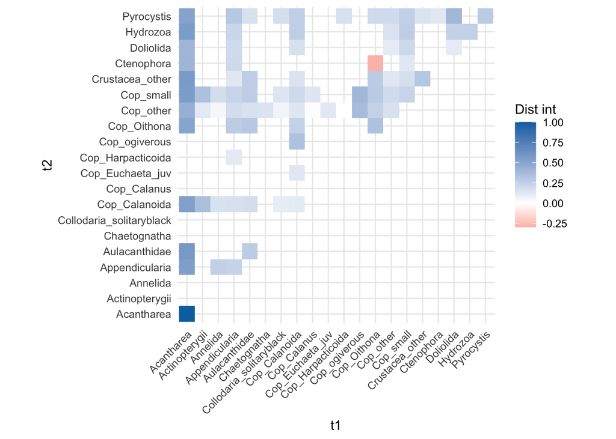

```r
# Plot matrix
ggplot(df_dist) +
  geom_raster(aes(x = t1, y = t2, fill = dist_int)) +
  labs(x = "t1", y = "t2", fill = "Dist int") +
  coord_fixed() +
  scale_fill_gradient2(na.value = NA, low = "#ca0020", high = "#0571b0") +
  theme(axis.text.x = element_text(angle = 45, hjust = 1))
```

### Co-occurrence matrix

```r
load("data/15b.co_occurrence_matrix.Rdata")
# Keep revelant columns
df_cooc <- df_cooc %>%
  select(t1, t2, cooc_int)
summary(df_cooc)
```

```
      t1                 t2               cooc_int
 Length:378         Length:378         Min.   :-0.15948
 Class :character   Class :character   1st Qu.:-0.02917
 Mode  :character   Mode  :character   Median : 0.03295
                                       Mean   : 0.03976
                                       3rd Qu.: 0.06517
                                       Max.   : 0.71111
                                       NA's   :59
```

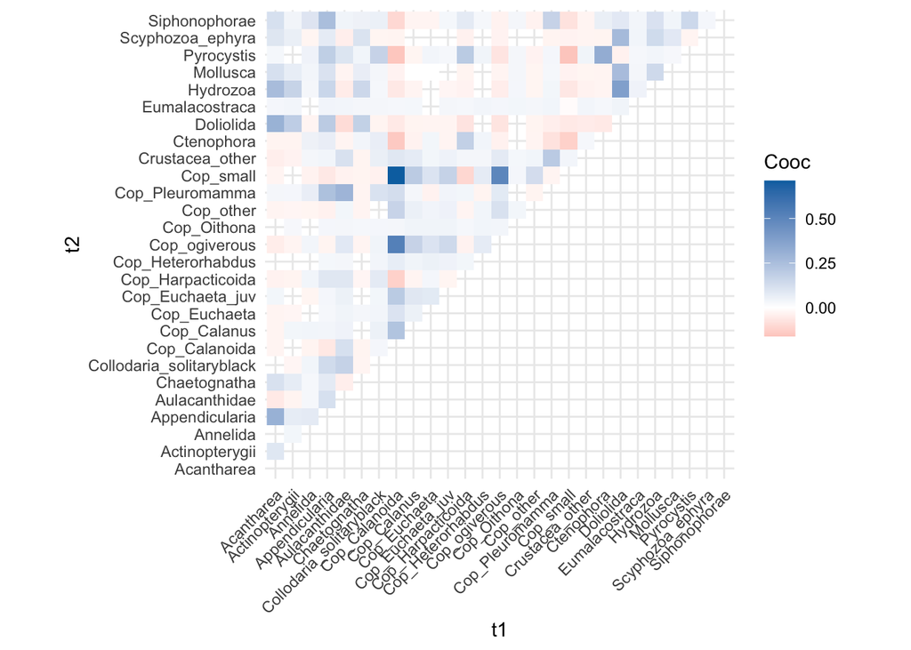

```r
# Plot the matrix
ggplot(df_cooc) +
  geom_raster(aes(x = t1, y = t2, fill = cooc_int)) +
  labs(x = "t1", y = "t2", fill = "Cooc") +
  coord_fixed() +
  scale_fill_gradient2(na.value = NA, low = "#ca0020", high = "#0571b0") +
  theme(axis.text.x = element_text(angle = 45, hjust = 1))
```

All good.

### Size-based matrix

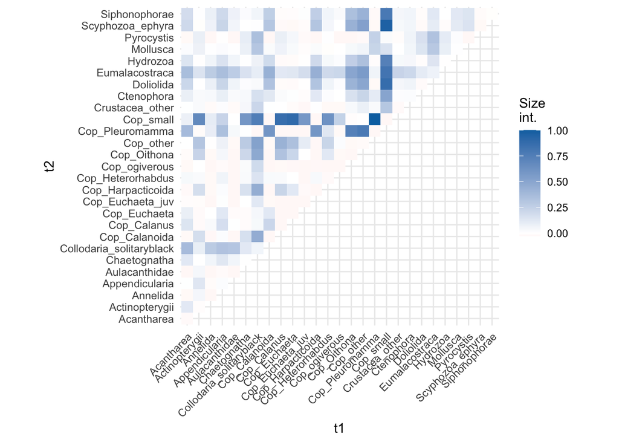

```r
load("data/16.size_matrix.Rdata")

# Plot the matrix
ggplot(df_size) +
  geom_raster(aes(x = t1, y = t2, fill = size_int)) +
  labs(x = "t1", y = "t2", fill = "Size\nint.") +
  coord_fixed() +
  scale_fill_gradient2(na.value = NA, low = "#ca0020", high = "#0571b0") +
  theme(axis.text.x = element_text(angle = 45, hjust = 1))
```

## Join matrices and plot

Let’s join the distance-based, co-occurrence and size-based matrices.

```r
# Assemble matrices
df_mat <- df_cooc %>%
  left_join(df_size, by = join_by(t1, t2)) %>%
  left_join(df_dist, by = join_by(t1, t2)) %>%
  mutate(pair = paste(t1, t2, sep = " - "), .after = t2)
summary(df_mat %>% select(contains("int")))
```

```
    cooc_int           size_int           dist_int
 Min.   :-0.15948   Min.   :-0.02756   Min.   :-0.2961
 1st Qu.:-0.02917   1st Qu.:-0.01495   1st Qu.: 0.1445
 Median : 0.03295   Median : 0.03096   Median : 0.2078
 Mean   : 0.03976   Mean   : 0.11022   Mean   : 0.2436
 3rd Qu.: 0.06517   3rd Qu.: 0.15653   3rd Qu.: 0.2898
 Max.   : 0.71111   Max.   : 1.00000   Max.   : 1.0000
 NA's   :59                            NA's   :293
```

All metrics could not be computed for each pair. This is something we need to account for when plotting.

Let’s do a first version where we drop all pairs for which at least one metric is missing.

### Drop missing

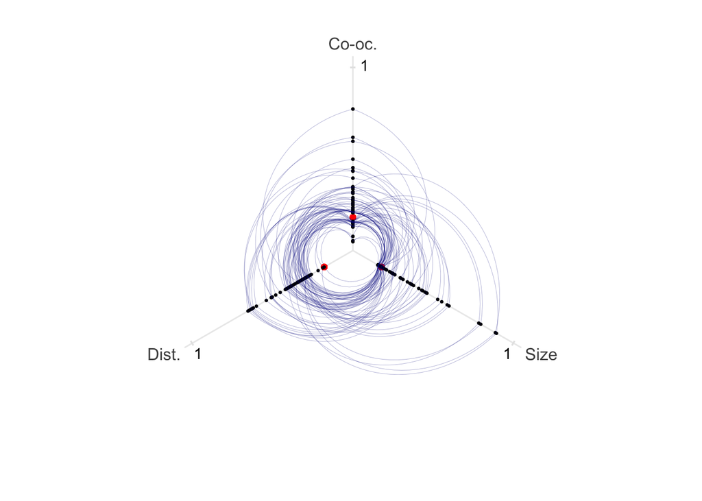

```r
# Drop pairs for which at least one value is missing
df_drop <- df_mat %>% drop_na()

# Reshape to longer df
df_drop_long <- df_drop %>% pivot_longer(cooc_int:dist_int, names_to = "method")

# Little trick for polar plot
# Duplicate the first variable to close the circle
df_drop_1 <- df_drop_long %>%
  arrange(method) %>%
  mutate(
    var = case_when(
      method == "cooc_int" ~ "1",
      method == "size_int" ~ "2",
      method == "dist_int" ~ "3",
    )
  )
df_drop_2 <- df_drop_1 %>%
  filter(var == "1") %>%
  mutate(var = "6") %>%
  bind_rows(df_drop_1)

# Circular plot
ggplot(df_drop_2, aes(x = var, y = value)) +
  # Ticks annotation
  annotate("text", x = c(1.03, 2.03, 2.97), y = 1, label = "1") +
  annotate("text", x = 1, y = 1, label = "-", colour = "grey90", size = 5) +
  geom_textpath(aes(x = 2, y = 1, label = "-"), linetype = 0, colour = "grey90", size = 5) +
  geom_textpath(aes(x = 3, y = 1, label = "-"), linetype = 0, colour = "grey90", size = 5) +
  geom_point(aes(x = var, y = 0), colour = "red") +
  # Points on axes
  geom_point(size = 0.5) +
  # Lines
  geom_line(aes(group = pair), alpha = 0.5, linewidth = 0.1, colour = "darkblue") +
  scale_x_discrete(expand = c(0, 0), breaks = c("1", "2", "3"), labels = c("1" = "Co-oc.", "2" = "Size", "3" = "Dist.")) +
  coord_radial() +
  theme(
    panel.background = element_blank(),
    panel.grid.major.y = element_blank(),
    panel.grid.minor.y = element_blank(),
    axis.ticks = element_blank(),
    axis.text.y = element_blank(),
    axis.title = element_blank(),
    axis.text.x = element_text(size = 12)
  )
```

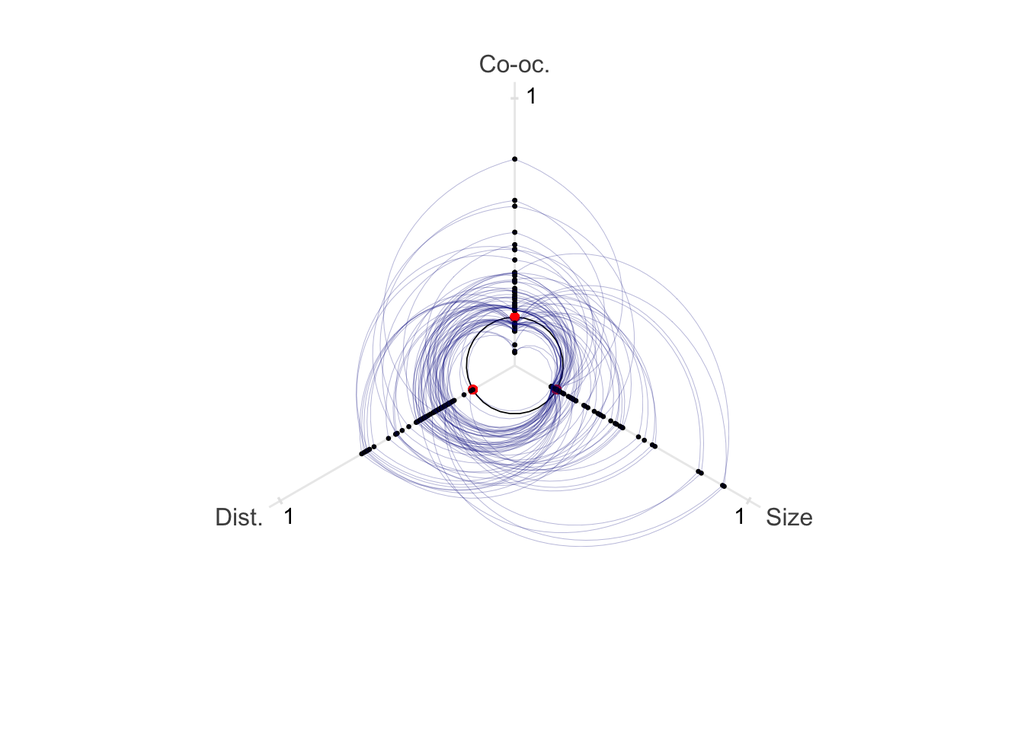

```r
# Circular plot
ggplot(df_drop_2, aes(x = var, y = value)) +
  # Ticks annotation
  annotate("text", x = c(1.03, 2.03, 2.97), y = 1, label = "1") +
  annotate("text", x = 1, y = 1, label = "-", colour = "grey90", size = 5) +
  geom_textpath(aes(x = 2, y = 1, label = "-"), linetype = 0, colour = "grey90", size = 5) +
  geom_textpath(aes(x = 3, y = 1, label = "-"), linetype = 0, colour = "grey90", size = 5) +
  geom_hline(yintercept = 0, linewidth = 0.3, colour = "black") +
  geom_point(aes(x = var, y = 0), colour = "red") +
  # Points on axes
  geom_point(size = 0.5) +
  # Lines
  geom_line(aes(group = pair), alpha = 0.5, linewidth = 0.1, colour = "darkblue") +
  scale_x_discrete(expand = c(0, 0), breaks = c("1", "2", "3"), labels = c("1" = "Co-oc.", "2" = "Size", "3" = "Dist.")) +
  coord_radial() +
  theme(
    panel.background = element_blank(),
    panel.grid.major.y = element_blank(),
    panel.grid.minor.y = element_blank(),
    axis.ticks = element_blank(),
    axis.text.y = element_blank(),
    axis.title = element_blank(),
    axis.text.x = element_text(size = 12)
  )
```

In this version, we have the same number of lines between each axes, but values do not go to 1 anymore.

Let’s try without dropping, but highlight these with a different colour.

### Retain missing

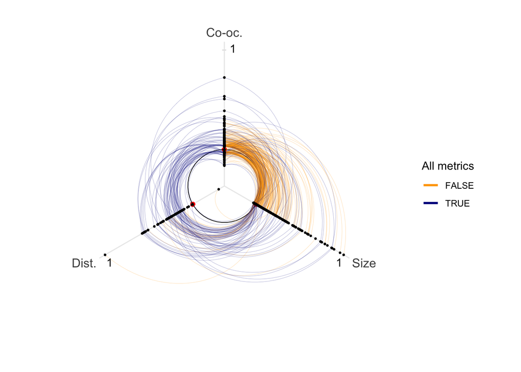

```r
# Reain pairs for which at least one value is missing but flag them
df_retain <- df_mat %>%
  rowwise() %>%
  # if mean(cooc_int, dist_int, size_int) is NA, then one is missing
  mutate(missing = is.na(sum(c_across(cooc_int:dist_int)))) %>%
  ungroup()

# Reshape to longer df
df_retain_long <- df_retain %>% pivot_longer(cooc_int:dist_int, names_to = "method")

# Little trick for polar plot
# Duplicate the first variable to close the circle
df_retain_1 <- df_retain_long %>%
  arrange(method) %>%
  mutate(
    var = case_when(
      method == "cooc_int" ~ "1",
      method == "size_int" ~ "2",
      method == "dist_int" ~ "3",
    )
  )
df_retain_2 <- df_retain_1 %>%
  filter(var == "1") %>%
  mutate(var = "6") %>%
  bind_rows(df_retain_1)

# Circular plot
ggplot(df_retain_2, aes(x = var, y = value)) +
  # Ticks annotation
  annotate("text", x = c(1.03, 2.03, 2.97), y = 1, label = "1") +
  annotate("text", x = 1, y = 1, label = "-", colour = "grey90", size = 5) +
  geom_textpath(aes(x = 2, y = 1, label = "-"), linetype = 0, colour = "grey90", size = 5) +
  geom_textpath(aes(x = 3, y = 1, label = "-"), linetype = 0, colour = "grey90", size = 5) +
  geom_point(aes(x = var, y = 0), colour = "red") +
  geom_hline(yintercept = 0, linewidth = 0.3, colour = "black") +
  # Lines
  geom_line(aes(group = pair, colour = !missing, alpha = missing), linewidth = 0.1) +
  # Points on axes
  geom_point(size = 0.5) +
  scale_x_discrete(expand = c(0, 0), breaks = c("1", "2", "3"), labels = c("1" = "Co-oc.", "2" = "Size", "3" = "Dist.")) +
  labs(colour = "All metrics", alpha = "All metrics") +
  scale_colour_manual(values = c("TRUE" = "darkblue", "FALSE" = "orange")) +
  scale_alpha_manual(values = c(0.5, 0.5)) +
  coord_radial() +
  theme(
    panel.background = element_blank(),
    panel.grid.major.y = element_blank(),
    panel.grid.minor.y = element_blank(),
    axis.ticks = element_blank(),
    axis.text.y = element_blank(),
    axis.title = element_blank(),
    axis.text.x = element_text(size = 12)
  ) +
  guides(colour = guide_legend(override.aes = list(alpha = 1, linewidth = 1)))
```

Let’s check what happens if we hide the orange lines. It should be the same plot as when dropping pairs with one missing value.

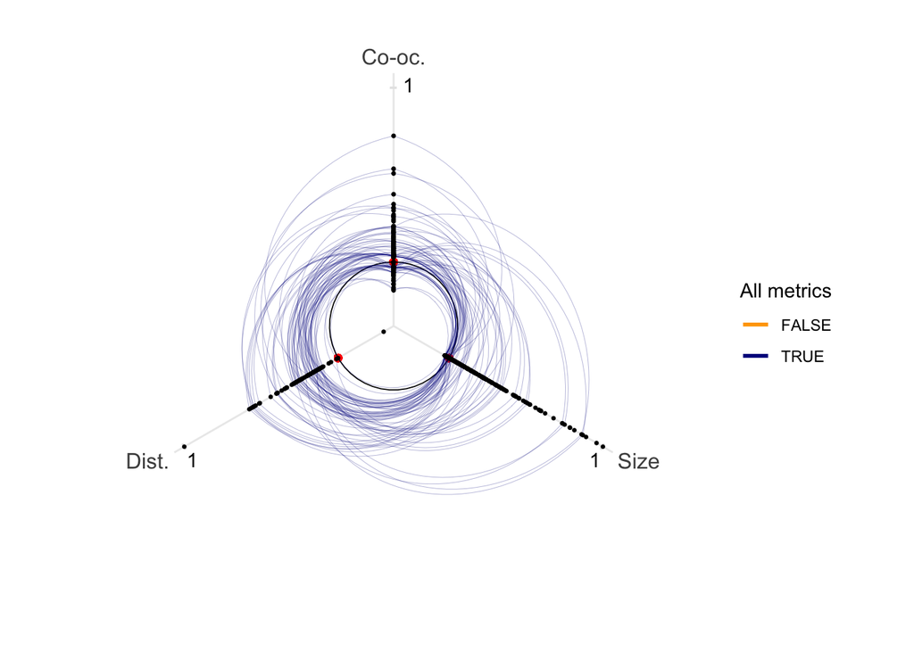

```r
# Circular plot
ggplot(df_retain_2, aes(x = var, y = value)) +
  # Ticks annotation
  annotate("text", x = c(1.03, 2.03, 2.97), y = 1, label = "1") +
  annotate("text", x = 1, y = 1, label = "-", colour = "grey90", size = 5) +
  geom_textpath(aes(x = 2, y = 1, label = "-"), linetype = 0, colour = "grey90", size = 5) +
  geom_textpath(aes(x = 3, y = 1, label = "-"), linetype = 0, colour = "grey90", size = 5) +
  geom_point(aes(x = var, y = 0), colour = "red") +
  geom_hline(yintercept = 0, linewidth = 0.3, colour = "black") +
  # Lines
  geom_line(aes(group = pair, colour = !missing, alpha = missing), linewidth = 0.1) +
  # Points on axes
  geom_point(size = 0.5) +
  scale_x_discrete(expand = c(0, 0), breaks = c("1", "2", "3"), labels = c("1" = "Co-oc.", "2" = "Size", "3" = "Dist.")) +
  labs(colour = "All metrics", alpha = "All metrics") +
  scale_colour_manual(values = c("TRUE" = "darkblue", "FALSE" = "orange")) +
  scale_alpha_manual(values = c(0.5, 0)) +
  coord_radial() +
  theme(
    panel.background = element_blank(),
    panel.grid.major.y = element_blank(),
    panel.grid.minor.y = element_blank(),
    axis.ticks = element_blank(),
    axis.text.y = element_blank(),
    axis.title = element_blank(),
    axis.text.x = element_text(size = 12)
  ) +
  guides(colour = guide_legend(override.aes = list(alpha = 1, linewidth = 1)))
```

All good!

**Note**

Which version do we want? I think the version with blue and orange lines is more informative. It highlights that the distance-based method finds fewer interactions.

Let’s try adding correlation values on the plot.

### Add correlation to plot

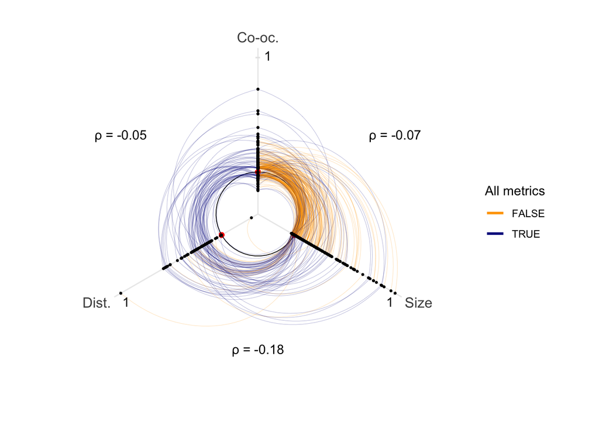

```r
# Compute correlations for each pair of metrics
corr_size_cooc <- cor(
  df_retain$size_int,
  df_retain$cooc_int,
  method = "spearman",
  use = "complete.obs"
)

corr_size_dist <- cor(
  df_retain$size_int,
  df_retain$dist_int,
  method = "spearman",
  use = "complete.obs"
)

corr_dist_cooc <- cor(
  df_retain$dist_int,
  df_retain$cooc_int,
  method = "spearman",
  use = "complete.obs"
)

# Circular plot with correlations
ggplot(df_retain_2, aes(x = var, y = value)) +
  # Ticks annotation
  annotate("text", x = c(1.03, 2.03, 2.97), y = 1, label = "1") +
  annotate("text", x = 1, y = 1, label = "-", colour = "grey90", size = 5) +
  geom_textpath(aes(x = 2, y = 1, label = "-"), linetype = 0, colour = "grey90", size = 5) +
  geom_textpath(aes(x = 3, y = 1, label = "-"), linetype = 0, colour = "grey90", size = 5) +
  geom_point(aes(x = var, y = 0), colour = "red") +
  geom_hline(yintercept = 0, linewidth = 0.3, colour = "black") +
  # Lines
  geom_line(aes(group = pair, colour = !missing, alpha = missing), linewidth = 0.1) +
  # Points on axes
  geom_point(size = 0.5) +
  scale_x_discrete(expand = c(0, 0), breaks = c("1", "2", "3"), labels = c("1" = "Co-oc.", "2" = "Size", "3" = "Dist.")) +
  labs(colour = "All metrics", alpha = "All metrics") +
  scale_colour_manual(values = c("TRUE" = "darkblue", "FALSE" = "orange")) +
  scale_alpha_manual(values = c(0.5, 0.5)) +
  # Correlation values
  annotate("text", x = 1.5, y = 1, label = paste0("ρ = ", round(corr_size_cooc, digits = 2))) +
  annotate("text", x = 2.5, y = 0.8, label = paste0("ρ = ", round(corr_size_dist, digits = 2))) +
  annotate("text", x = 3.5, y = 1, label = paste0("ρ = ", round(corr_dist_cooc, digits = 2))) +
  coord_radial() +
  theme(
    panel.background = element_blank(),
    panel.grid.major.y = element_blank(),
    panel.grid.minor.y = element_blank(),
    axis.ticks = element_blank(),
    axis.text.y = element_blank(),
    axis.title = element_blank(),
    axis.text.x = element_text(size = 12)
  ) +
  guides(colour = guide_legend(override.aes = list(alpha = 1, linewidth = 1)))
```

## Mantel test

### First version: fill NA with 0

Matrices need to be complete: fill NA with 0.

```r
# List taxa
taxa <- sort(unique(df_cooc$t1))

# Prepare common dataframe
df_cross <- crossing(t1 = taxa, t2 = taxa) %>% filter(t1 < t2)

# Replace NA by zero
df_cooc_fill <- df_cross %>% left_join(df_cooc, by = join_by(t1, t2))
df_size_fill <- df_cross %>% left_join(df_size, by = join_by(t1, t2))
df_dist_fill <- df_cross %>% left_join(df_dist, by = join_by(t1, t2))


# To matrix
cooc_met <- df_cooc_fill %>%
  pivot_wider(names_from = t2, values_from = cooc_int) %>%
  column_to_rownames(var = "t1") %>%
  as.matrix()

size_met <- df_size_fill %>%
  pivot_wider(names_from = t2, values_from = size_int) %>%
  column_to_rownames(var = "t1") %>%
  as.matrix()

dist_met <- df_dist_fill %>%
  pivot_wider(names_from = t2, values_from = dist_int) %>%
  column_to_rownames(var = "t1") %>%
  as.matrix()

# Symmetrize the matrix
cooc_met[lower.tri(cooc_met)] = t(cooc_met)[lower.tri(cooc_met)]
size_met[lower.tri(size_met)] = t(size_met)[lower.tri(size_met)]
dist_met[lower.tri(dist_met)] = t(dist_met)[lower.tri(dist_met)]

# As distance matrix
cooc_met <- as.dist(cooc_met, diag = TRUE, upper = FALSE)
size_met <- as.dist(size_met, diag = TRUE, upper = FALSE)
dist_met <- as.dist(dist_met, diag = TRUE, upper = FALSE)

# Replace NA by 0
cooc_met[is.na(cooc_met)] <- 0
size_met[is.na(size_met)] <- 0
dist_met[is.na(dist_met)] <- 0

# Mantel test
m2_cs <- mantel(cooc_met, size_met, method = "spearman")
m2_cd <- mantel(cooc_met, dist_met, method = "spearman")
m2_sd <- mantel(size_met, dist_met, method = "spearman")
```

Display all Mantel tests results in a single table.

```r
m_res <- m2_cs
mantel_res <- lapply(list(m2_cs, m2_cd, m2_sd), function(m_res) {
  tibble(
    # Names of tested metrics
    pair = paste(as.character(m_res$call)[2], as.character(m_res$call)[3], sep = " - "),
    stat = m_res$statistic,
    signif = m_res$signif
  )
}) %>%
  bind_rows()
mantel_res
```

```
# A tibble: 3 × 3
  pair                   stat signif
  <chr>                 <dbl>  <dbl>
1 cooc_met - size_met -0.0415  0.764
2 cooc_met - dist_met  0.0146  0.392
3 size_met - dist_met -0.0501  0.776
```

### Second version: keep only non empty row and columns

For this case, we only retain taxa with which we can build a complete matrix. For this we need to iterate over taxonomic groups and retain only those for which we have the distance metric.

```r
# Initiate empty list of retained taxa
retained_taxa <- c()

## Successively add taxa using walk
walk(taxa, function(new_taxon) {
  df_add <- df_cross %>%
    # Add new taxon and keep previously added taxa
    filter((t1 %in% c(new_taxon, retained_taxa)) & (t2 %in% c(new_taxon, retained_taxa))) %>%
    left_join(df_dist, by = join_by(t1, t2))

  # Check if NA in added values
  if (!any(is.na(df_add$dist_int))) {
    # If not NA, then add taxon to retained taxa
    retained_taxa <<- c(retained_taxa, new_taxon)
  }
})
```

This is the list of retained taxa: Acantharea, Appendicularia, Cop_Calanoida, Cop_Oithona, Cop_other, Cop_small, Crustacea_other, Pyrocystis

Let’s keep only these taxa in all matrices.

```r
df_dist_ret <- df_dist %>%
  filter(t1 %in% retained_taxa & t2 %in% retained_taxa)
summary(df_dist_ret %>% filter(t1 != t2))
```

```
      t1                 t2               dist_int
 Length:28          Length:28          Min.   :0.1258
 Class :character   Class :character   1st Qu.:0.1783
 Mode  :character   Mode  :character   Median :0.2437
                                       Mean   :0.2856
                                       3rd Qu.:0.3305
                                       Max.   :0.5656
```

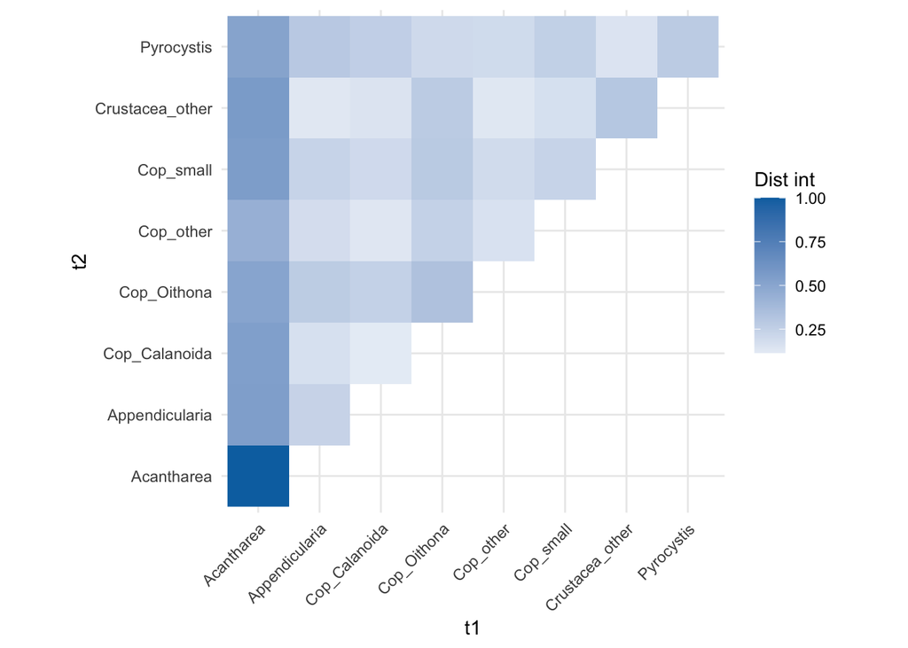

```r
# Plot our new distance matrix
ggplot(df_dist_ret) +
  geom_raster(aes(x = t1, y = t2, fill = dist_int)) +
  labs(x = "t1", y = "t2", fill = "Dist int") +
  coord_fixed() +
  scale_fill_gradient2(na.value = NA, low = "#ca0020", high = "#0571b0") +
  theme(axis.text.x = element_text(angle = 45, hjust = 1))
```

```r
df_cooc_ret <- df_cooc %>%
  filter(t1 %in% retained_taxa & t2 %in% retained_taxa)
summary(df_cooc_ret %>% filter(t1 != t2))
```

```
      t1                 t2               cooc_int
 Length:28          Length:28          Min.   :-0.15948
 Class :character   Class :character   1st Qu.:-0.03129
 Mode  :character   Mode  :character   Median : 0.03148
                                       Mean   : 0.04912
                                       3rd Qu.: 0.04028
                                       Max.   : 0.71111
                                       NA's   :1
```

```r
df_size_ret <- df_size %>%
  filter(t1 %in% retained_taxa & t2 %in% retained_taxa)
summary(df_size_ret %>% filter(t1 != t2))
```

```
      t1                 t2               size_int
 Length:28          Length:28          Min.   :-0.027561
 Class :character   Class :character   1st Qu.:-0.023220
 Mode  :character   Mode  :character   Median :-0.001461
                                       Mean   : 0.021864
                                       3rd Qu.: 0.022121
                                       Max.   : 0.303211
```

We have one NA is the co-occurrence matrix. Let’s replace it by zero.

```r
df_cooc_ret <- df_cooc_ret %>% mutate(cooc_int = replace_na(cooc_int, 0))
```

Let’s now convert all this to matrices and perform Mantel test.

```r
# To matrix
cooc_met <- df_cooc_ret %>%
  pivot_wider(names_from = t2, values_from = cooc_int) %>%
  column_to_rownames(var = "t1") %>%
  as.matrix()

size_met <- df_size_ret %>%
  pivot_wider(names_from = t2, values_from = size_int) %>%
  column_to_rownames(var = "t1") %>%
  as.matrix()

dist_met <- df_dist_ret %>%
  pivot_wider(names_from = t2, values_from = dist_int) %>%
  column_to_rownames(var = "t1") %>%
  as.matrix()

# Symmetrize the matrix
cooc_met[lower.tri(cooc_met)] = t(cooc_met)[lower.tri(cooc_met)]
size_met[lower.tri(size_met)] = t(size_met)[lower.tri(size_met)]
dist_met[lower.tri(dist_met)] = t(dist_met)[lower.tri(dist_met)]

# As distance matrix, do not keep the diagonal
cooc_met <- as.dist(cooc_met, diag = FALSE, upper = FALSE)
size_met <- as.dist(size_met, diag = FALSE, upper = FALSE)
dist_met <- as.dist(dist_met, diag = FALSE, upper = FALSE)

# Mantel test
mantel(cooc_met, size_met, method = "spearman")
```

```
Mantel statistic based on Spearman's rank correlation rho

Call:
mantel(xdis = cooc_met, ydis = size_met, method = "spearman")

Mantel statistic r: -0.2483
      Significance: 0.925

Upper quantiles of permutations (null model):
  90%   95% 97.5%   99%
0.182 0.230 0.272 0.321
Permutation: free
Number of permutations: 999
```

```r
mantel(cooc_met, dist_met, method = "spearman")
```

```
Mantel statistic based on Spearman's rank correlation rho

Call:
mantel(xdis = cooc_met, ydis = dist_met, method = "spearman")

Mantel statistic r: -0.3049
      Significance: 0.977

Upper quantiles of permutations (null model):
  90%   95% 97.5%   99%
0.176 0.221 0.255 0.297
Permutation: free
Number of permutations: 999
```

```r
mantel(size_met, dist_met, method = "spearman")
```

```
Mantel statistic based on Spearman's rank correlation rho

Call:
mantel(xdis = size_met, ydis = dist_met, method = "spearman")

Mantel statistic r: -0.09908
      Significance: 0.6

Upper quantiles of permutations (null model):
  90%   95% 97.5%   99%
0.375 0.442 0.498 0.579
Permutation: free
Number of permutations: 999
```

Let’s use the size-based association metric as the truth, using a binary classification of whether or not there is an association. Let’s then see if distance-based and co-occurrence metrics can retrieve this truth.

```r
## Convert association metrics to binary values: TRUE for an association, FALSE for no association
# Size-based values: "truth"
# Flag negative size values as NA: these are the cases with no association.
df_size_bin <- df_size %>%
  mutate(size_assoc = ifelse(size_int <= 0, FALSE, TRUE)) %>%
  select(-size_int)
summary(df_size_bin)
```

```
      t1                 t2            size_assoc
 Length:378         Length:378         Mode :logical
 Class :character   Class :character   FALSE:131
 Mode  :character   Mode  :character   TRUE :247
```

```r
# Distance-based values
df_dist_bin <- df_dist %>%
  mutate(dist_assoc = ifelse(is.na(dist_int), FALSE, TRUE)) %>%
  select(-dist_int)

# Co-occurrence values
df_cooc_bin <- df_cooc %>%
  mutate(cooc_assoc = ifelse(is.na(cooc_int), FALSE, TRUE)) %>%
  select(-cooc_int)


## Store all together
# Prepare all combinations of pairs
df_comp_bin <- df_cross %>%
  # Join true association, based on size
  left_join(df_size_bin, by = join_by(t1, t2)) %>%
  # Join distance based metric
  left_join(df_dist_bin, by = join_by(t1, t2)) %>%
  # Join co-occurrence metric
  left_join(df_cooc_bin, by = join_by(t1, t2)) %>%
  # Replace NA in distance association by FALSE for no association
  mutate(dist_assoc = replace_na(dist_assoc, FALSE))
summary(df_comp_bin)
```

```
      t1                 t2            size_assoc      dist_assoc
 Length:351         Length:351         Mode :logical   Mode :logical
 Class :character   Class :character   FALSE:110       FALSE:277
 Mode  :character   Mode  :character   TRUE :241       TRUE :74
 cooc_assoc
 Mode :logical
 FALSE:32
 TRUE :319
```

```r
## Compute precision and recall
# Function to compute accuracy, precision and recall
compute_metrics <- function(data, truth_col, pred_col) {
  accuracy <- Accuracy(
    y_true = as.factor(data[[truth_col]]),
    y_pred = as.factor(data[[pred_col]])
  )
  precision <- Precision(
    y_true = as.factor(data[[truth_col]]),
    y_pred = as.factor(data[[pred_col]]),
    positive = TRUE
  )
  recall <- Recall(
    y_true = as.factor(data[[truth_col]]),
    y_pred = as.factor(data[[pred_col]]),
    positive = TRUE
  )
  # Return results in a tibble
  tibble(method = pred_col, accuracy = accuracy, precision = precision, recall = recall)
}

# Compute metrics for distance and co-occurrence metrics
metrics <- bind_rows(
  compute_metrics(df_comp_bin, "size_assoc", "dist_assoc"),
  compute_metrics(df_comp_bin, "size_assoc", "cooc_assoc")
)

# Print the results
print(metrics)
```

```
# A tibble: 2 × 4
  method     accuracy precision recall
  <chr>         <dbl>     <dbl>  <dbl>
1 dist_assoc    0.353     0.595  0.183
2 cooc_assoc    0.670     0.696  0.921
```

## Explore specific cases highlighted in the paper

### Acantharea

According to the distance-based metric, Acantharea may be interacting with each other. We can’t compute the co-occurrence metric for intra-group, but let’s have a look at what was expected regarding the size-based metric.

```r
# Get the size-based metric for Acantharea
size_acant <- df_size %>% filter(t1 == "Acantharea" & t2 == "Acantharea")
size_acant
```

```
# A tibble: 1 × 3
  t1         t2         size_int
  <chr>      <chr>         <dbl>
1 Acantharea Acantharea  -0.0220
```

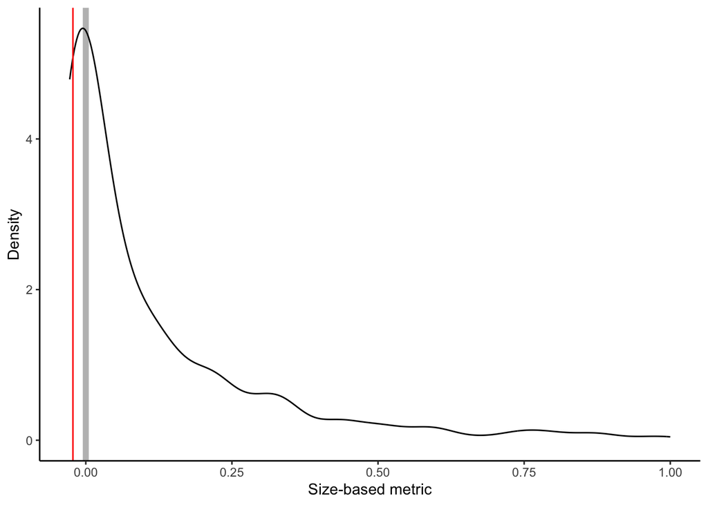

```r
# Plot distribution of size-based interactions
ggplot(df_size) +
  geom_vline(xintercept = 0, colour = "grey", linewidth = 2) +
  geom_density(aes(x = size_int)) +
  geom_vline(xintercept = size_acant$size_int, colour = "red") +
  labs(x = "Size-based metric", y = "Density") +
  theme_classic()
```

The size-based metric for Acantharea (red vertical line) predicts a less-than-random predation within the group.

### Ctenophora - Oithona

In intergroup distances, Ctenophora and Oithona were found to be further away than expected. Let’s check what was predicted by the co-occurrence and size-based metrics.

```r
# Get size-based metric for the pair of interest
size_cteno_oitho <- df_size %>% filter(t1 == "Cop_Oithona" & t2 == "Ctenophora")
size_cteno_oitho
```

```
# A tibble: 1 × 3
  t1          t2         size_int
  <chr>       <chr>         <dbl>
1 Cop_Oithona Ctenophora    0.161
```

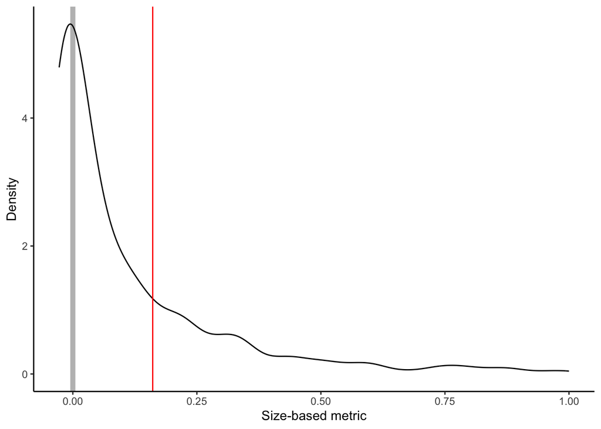

```r
# Plot distribution of size-based interactions
ggplot(df_size) +
  geom_vline(xintercept = 0, colour = "grey", linewidth = 2) +
  geom_density(aes(x = size_int)) +
  geom_vline(xintercept = size_cteno_oitho$size_int, colour = "red") +
  labs(x = "Size-based metric", y = "Density") +
  theme_classic()
```

The size-based metric predicts a somewhat high predation probability between Ctenophora and Oithona. Let’s check the size distribution of both groups.

```r
#|cache: false

# Read plankton and images
plankton <- read_parquet("data/00.plankton_clean.parquet")
# Keep only groups of interest
plankton <- plankton %>% filter(taxon %in% c("Ctenophora", "Cop_Oithona"))
gc()
```

```
           used  (Mb) gc trigger   (Mb) limit (Mb)  max used   (Mb)
Ncells  4101758 219.1   46790056 2498.9         NA  22067683 1178.6
Vcells 33247422 253.7  283396136 2162.2      65536 295137641 2251.8
```

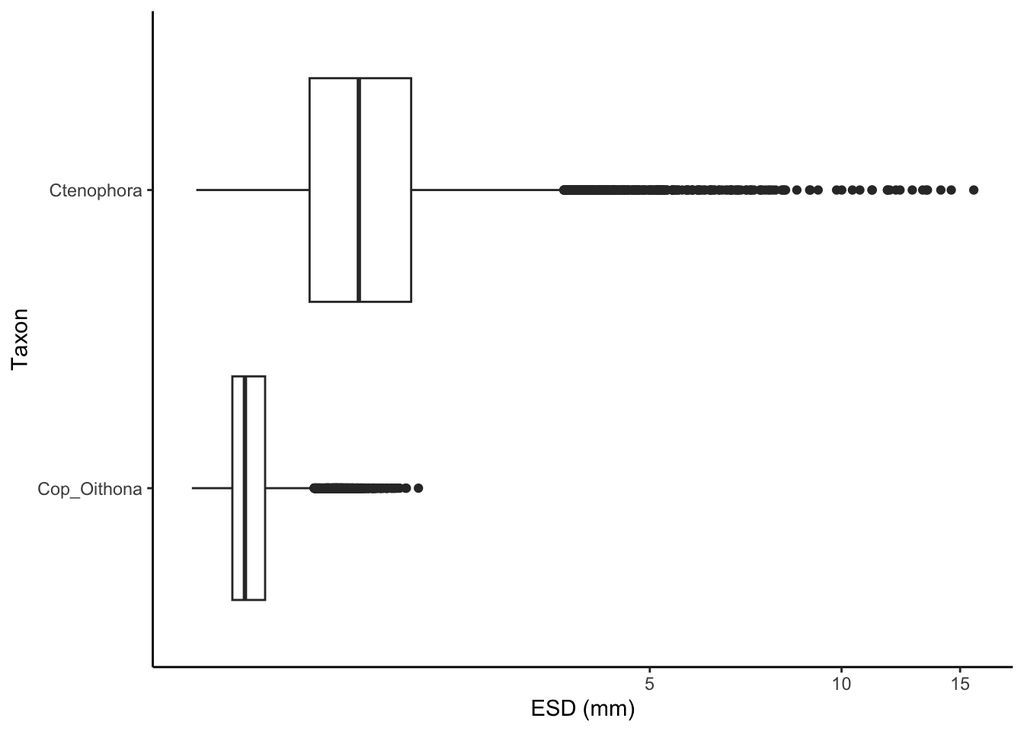

```r
# Convert ESD from px to mm
plankton <- plankton %>% mutate(esd = esd * 51 / 1000)

# Randomly select 10,000 objects of each taxon
plankton <- plankton %>%
  group_by(taxon) %>%
  slice_sample(n = 10000) %>%
  ungroup()

# Plot boxplots of ESD
ggplot(plankton) +
  geom_boxplot(aes(x = esd, y = taxon)) +
  scale_x_continuous(trans = "log1p") +
  labs(x = "ESD (mm)", y = "Taxon") +
  theme_classic()
```

Ctenophora is indeed bigger than Oithona, predation by Ctenophora on Oithona makes sense.

Let’s now have a look at the co-occurrence metric.

```r
# Get co-occurrence metric for the pair of interest
cooc_cteno_oitho <- df_cooc %>% filter(t1 == "Cop_Oithona" & t2 == "Ctenophora")
cooc_cteno_oitho
```

```
# A tibble: 1 × 3
  t1          t2         cooc_int
  <chr>       <chr>         <dbl>
1 Cop_Oithona Ctenophora      NaN
```

It’s NaN, because the correlation was not significant.